# Risk Factor Analysis

## Outcome Variable

**Outcome Variable:** ever_wasted

## Predictor Variables

**Intervention Variable:** perdiar6

**Adjustment Set:**

- arm
- sex
- W_mage
- meducyrs
- W_mhtcm
- W_mwtkg
- W_mbmi
- W_birthwt
- W_birthlen
- W_nrooms
- month
- brthmon
- impfloor
- impsan
- safeh20
- delta_W_mage
- delta_meducyrs
- delta_W_mhtcm
- delta_W_mwtkg
- delta_W_mbmi
- delta_W_birthwt
- delta_W_birthlen
- delta_W_nrooms
- delta_month
- delta_brthmon
- delta_impfloor
- delta_impsan
- delta_safeh20

## Stratifying Variables

The analysis was stratified on these variable(s):

- agecat
- studyid
- country

## Data Summary

| agecat | studyid | country | perdiar6 | ever_wasted | n_cell | n |
| --- | --- | --- | --- | --- | --- | --- |
| 0-24 months (no birth wast) | ki0047075b-MAL-ED | BANGLADESH | 0% | 0 | 65 | 263 |
| 0-24 months (no birth wast) | ki0047075b-MAL-ED | BANGLADESH | 0% | 1 | 20 | 263 |
| 0-24 months (no birth wast) | ki0047075b-MAL-ED | BANGLADESH | (0%, 5%] | 0 | 75 | 263 |
| 0-24 months (no birth wast) | ki0047075b-MAL-ED | BANGLADESH | (0%, 5%] | 1 | 23 | 263 |
| 0-24 months (no birth wast) | ki0047075b-MAL-ED | BANGLADESH | >5% | 0 | 65 | 263 |
| 0-24 months (no birth wast) | ki0047075b-MAL-ED | BANGLADESH | >5% | 1 | 15 | 263 |
| 0-24 months (no birth wast) | ki0047075b-MAL-ED | BRAZIL | 0% | 0 | 205 | 232 |
| 0-24 months (no birth wast) | ki0047075b-MAL-ED | BRAZIL | 0% | 1 | 10 | 232 |
| 0-24 months (no birth wast) | ki0047075b-MAL-ED | BRAZIL | (0%, 5%] | 0 | 14 | 232 |
| 0-24 months (no birth wast) | ki0047075b-MAL-ED | BRAZIL | (0%, 5%] | 1 | 1 | 232 |
| 0-24 months (no birth wast) | ki0047075b-MAL-ED | BRAZIL | >5% | 0 | 1 | 232 |
| 0-24 months (no birth wast) | ki0047075b-MAL-ED | BRAZIL | >5% | 1 | 1 | 232 |
| 0-24 months (no birth wast) | ki0047075b-MAL-ED | INDIA | 0% | 0 | 36 | 246 |
| 0-24 months (no birth wast) | ki0047075b-MAL-ED | INDIA | 0% | 1 | 23 | 246 |
| 0-24 months (no birth wast) | ki0047075b-MAL-ED | INDIA | (0%, 5%] | 0 | 86 | 246 |
| 0-24 months (no birth wast) | ki0047075b-MAL-ED | INDIA | (0%, 5%] | 1 | 42 | 246 |
| 0-24 months (no birth wast) | ki0047075b-MAL-ED | INDIA | >5% | 0 | 35 | 246 |
| 0-24 months (no birth wast) | ki0047075b-MAL-ED | INDIA | >5% | 1 | 24 | 246 |
| 0-24 months (no birth wast) | ki0047075b-MAL-ED | NEPAL | 0% | 0 | 65 | 239 |
| 0-24 months (no birth wast) | ki0047075b-MAL-ED | NEPAL | 0% | 1 | 18 | 239 |
| 0-24 months (no birth wast) | ki0047075b-MAL-ED | NEPAL | (0%, 5%] | 0 | 63 | 239 |
| 0-24 months (no birth wast) | ki0047075b-MAL-ED | NEPAL | (0%, 5%] | 1 | 13 | 239 |
| 0-24 months (no birth wast) | ki0047075b-MAL-ED | NEPAL | >5% | 0 | 66 | 239 |
| 0-24 months (no birth wast) | ki0047075b-MAL-ED | NEPAL | >5% | 1 | 14 | 239 |
| 0-24 months (no birth wast) | ki0047075b-MAL-ED | PERU | 0% | 0 | 83 | 302 |
| 0-24 months (no birth wast) | ki0047075b-MAL-ED | PERU | 0% | 1 | 6 | 302 |
| 0-24 months (no birth wast) | ki0047075b-MAL-ED | PERU | (0%, 5%] | 0 | 88 | 302 |
| 0-24 months (no birth wast) | ki0047075b-MAL-ED | PERU | (0%, 5%] | 1 | 5 | 302 |
| 0-24 months (no birth wast) | ki0047075b-MAL-ED | PERU | >5% | 0 | 111 | 302 |
| 0-24 months (no birth wast) | ki0047075b-MAL-ED | PERU | >5% | 1 | 9 | 302 |

[output cut: 258 more lines]

The following strata were considered:

- agecat: 0-24 months (no birth wast), studyid: ki0047075b-MAL-ED, country: BANGLADESH
- agecat: 0-24 months (no birth wast), studyid: ki0047075b-MAL-ED, country: BRAZIL
- agecat: 0-24 months (no birth wast), studyid: ki0047075b-MAL-ED, country: INDIA
- agecat: 0-24 months (no birth wast), studyid: ki0047075b-MAL-ED, country: NEPAL
- agecat: 0-24 months (no birth wast), studyid: ki0047075b-MAL-ED, country: PERU
- agecat: 0-24 months (no birth wast), studyid: ki0047075b-MAL-ED, country: SOUTH AFRICA
- agecat: 0-24 months (no birth wast), studyid: ki0047075b-MAL-ED, country: TANZANIA, UNITED REPUBLIC OF
- agecat: 0-24 months (no birth wast), studyid: ki1000109-ResPak, country: PAKISTAN
- agecat: 0-24 months (no birth wast), studyid: ki1017093-NIH-Birth, country: BANGLADESH
- agecat: 0-24 months (no birth wast), studyid: ki1017093b-PROVIDE, country: BANGLADESH
- agecat: 0-24 months (no birth wast), studyid: ki1017093c-NIH-Crypto, country: BANGLADESH
- agecat: 0-24 months (no birth wast), studyid: ki1114097-CMIN, country: BANGLADESH
- agecat: 0-24 months (no birth wast), studyid: ki1114097-CMIN, country: BRAZIL
- agecat: 0-24 months (no birth wast), studyid: ki1114097-CMIN, country: GUINEA-BISSAU
- agecat: 0-24 months (no birth wast), studyid: ki1114097-CMIN, country: PERU
- agecat: 0-24 months (no birth wast), studyid: ki1114097-CONTENT, country: PERU
- agecat: 0-6 months (no birth wast), studyid: ki0047075b-MAL-ED, country: BANGLADESH
- agecat: 0-6 months (no birth wast), studyid: ki0047075b-MAL-ED, country: BRAZIL
- agecat: 0-6 months (no birth wast), studyid: ki0047075b-MAL-ED, country: INDIA
- agecat: 0-6 months (no birth wast), studyid: ki0047075b-MAL-ED, country: NEPAL
- agecat: 0-6 months (no birth wast), studyid: ki0047075b-MAL-ED, country: PERU
- agecat: 0-6 months (no birth wast), studyid: ki0047075b-MAL-ED, country: SOUTH AFRICA
- agecat: 0-6 months (no birth wast), studyid: ki0047075b-MAL-ED, country: TANZANIA, UNITED REPUBLIC OF
- agecat: 0-6 months (no birth wast), studyid: ki1000109-ResPak, country: PAKISTAN
- agecat: 0-6 months (no birth wast), studyid: ki1017093-NIH-Birth, country: BANGLADESH
- agecat: 0-6 months (no birth wast), studyid: ki1017093b-PROVIDE, country: BANGLADESH
- agecat: 0-6 months (no birth wast), studyid: ki1017093c-NIH-Crypto, country: BANGLADESH
- agecat: 0-6 months (no birth wast), studyid: ki1114097-CMIN, country: BANGLADESH
- agecat: 0-6 months (no birth wast), studyid: ki1114097-CMIN, country: BRAZIL
- agecat: 0-6 months (no birth wast), studyid: ki1114097-CMIN, country: GUINEA-BISSAU
- agecat: 0-6 months (no birth wast), studyid: ki1114097-CMIN, country: PERU
- agecat: 0-6 months (no birth wast), studyid: ki1114097-CONTENT, country: PERU
- agecat: 6-24 months, studyid: ki0047075b-MAL-ED, country: BANGLADESH
- agecat: 6-24 months, studyid: ki0047075b-MAL-ED, country: BRAZIL
- agecat: 6-24 months, studyid: ki0047075b-MAL-ED, country: INDIA
- agecat: 6-24 months, studyid: ki0047075b-MAL-ED, country: NEPAL
- agecat: 6-24 months, studyid: ki0047075b-MAL-ED, country: PERU
- agecat: 6-24 months, studyid: ki0047075b-MAL-ED, country: SOUTH AFRICA
- agecat: 6-24 months, studyid: ki0047075b-MAL-ED, country: TANZANIA, UNITED REPUBLIC OF
- agecat: 6-24 months, studyid: ki1000109-ResPak, country: PAKISTAN
- agecat: 6-24 months, studyid: ki1017093-NIH-Birth, country: BANGLADESH
- agecat: 6-24 months, studyid: ki1017093b-PROVIDE, country: BANGLADESH
- agecat: 6-24 months, studyid: ki1017093c-NIH-Crypto, country: BANGLADESH
- agecat: 6-24 months, studyid: ki1114097-CMIN, country: BANGLADESH
- agecat: 6-24 months, studyid: ki1114097-CMIN, country: BRAZIL
- agecat: 6-24 months, studyid: ki1114097-CMIN, country: GUINEA-BISSAU
- agecat: 6-24 months, studyid: ki1114097-CMIN, country: PERU
- agecat: 6-24 months, studyid: ki1114097-CONTENT, country: PERU

### Dropped Strata

Some strata were dropped due to rare outcomes:

- agecat: 0-24 months (no birth wast), studyid: ki0047075b-MAL-ED, country: BRAZIL
- agecat: 0-24 months (no birth wast), studyid: ki0047075b-MAL-ED, country: SOUTH AFRICA
- agecat: 0-24 months (no birth wast), studyid: ki0047075b-MAL-ED, country: TANZANIA, UNITED REPUBLIC OF
- agecat: 0-24 months (no birth wast), studyid: ki1114097-CMIN, country: BRAZIL
- agecat: 0-24 months (no birth wast), studyid: ki1114097-CONTENT, country: PERU
- agecat: 0-6 months (no birth wast), studyid: ki0047075b-MAL-ED, country: BRAZIL
- agecat: 0-6 months (no birth wast), studyid: ki0047075b-MAL-ED, country: NEPAL
- agecat: 0-6 months (no birth wast), studyid: ki0047075b-MAL-ED, country: PERU
- agecat: 0-6 months (no birth wast), studyid: ki0047075b-MAL-ED, country: SOUTH AFRICA
- agecat: 0-6 months (no birth wast), studyid: ki0047075b-MAL-ED, country: TANZANIA, UNITED REPUBLIC OF
- agecat: 0-6 months (no birth wast), studyid: ki1114097-CMIN, country: BRAZIL
- agecat: 0-6 months (no birth wast), studyid: ki1114097-CMIN, country: GUINEA-BISSAU
- agecat: 0-6 months (no birth wast), studyid: ki1114097-CMIN, country: PERU
- agecat: 0-6 months (no birth wast), studyid: ki1114097-CONTENT, country: PERU
- agecat: 6-24 months, studyid: ki0047075b-MAL-ED, country: BRAZIL
- agecat: 6-24 months, studyid: ki0047075b-MAL-ED, country: PERU
- agecat: 6-24 months, studyid: ki0047075b-MAL-ED, country: SOUTH AFRICA
- agecat: 6-24 months, studyid: ki0047075b-MAL-ED, country: TANZANIA, UNITED REPUBLIC OF
- agecat: 6-24 months, studyid: ki1114097-CMIN, country: BRAZIL
- agecat: 6-24 months, studyid: ki1114097-CONTENT, country: PERU

## Methods Detail

We’re interested in the causal parameters $E[Y_a]$ for all values of $a \in \mathcal{A}$. These parameters represent the mean outcome if, possibly contrary to fact, we intervened to set all units to have $A=a$. Under the randomization and positivity assumptions, these are identified by the statistical parameters $\psi_a=E_W[E_{Y|A,W}(Y|A=a,W)]$. In addition, we’re interested in the mean of $Y$, $E[Y]$ under no intervention (the observed mean). We will estimate these parameters by using SuperLearner to fit the relevant likelihood factors – $E_{Y|A,W}(Y|A=a,W)$ and $p(A=a|W)$, and then updating our likelihood fit using a joint TMLE.

For unadjusted analyses ($W=\{\}$), initial likelihoods were estimated using Lrnr_glm to estimate the simple $E(Y|A)$ and Lrnr_mean to estimate $p(A)$. For adjusted analyses, a small library containing Lrnr_glmnet, Lrnr_xgboost, and Lrnr_mean was used.

Having estimated these parameters, we will then use the delta method to estimate relative risks and attributable risks relative to a prespecified baseline level of $A$.

# Results Detail

## Results Plots

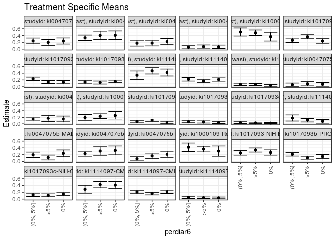

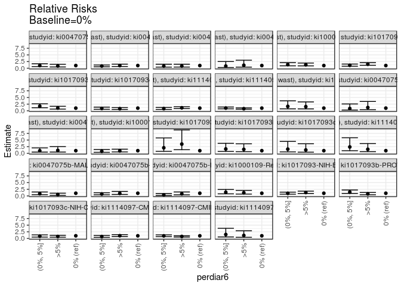

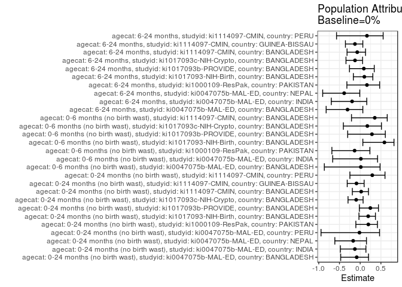

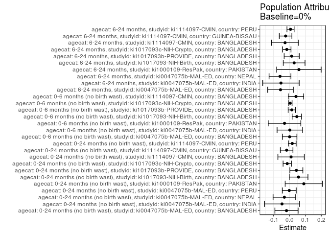

## Results Table

### Parameter: TSM

| agecat | studyid | country | intervention_level | baseline_level | estimate | ci_lower | ci_upper |
| --- | --- | --- | --- | --- | --- | --- | --- |
| 0-24 months (no birth wast) | ki0047075b-MAL-ED | BANGLADESH | 0% | NA | 0.2390672 | 0.1495016 | 0.3286328 |
| 0-24 months (no birth wast) | ki0047075b-MAL-ED | BANGLADESH | (0%, 5%] | NA | 0.2420218 | 0.1578922 | 0.3261515 |
| 0-24 months (no birth wast) | ki0047075b-MAL-ED | BANGLADESH | >5% | NA | 0.1987597 | 0.1121107 | 0.2854087 |
| 0-24 months (no birth wast) | ki0047075b-MAL-ED | INDIA | 0% | NA | 0.4084037 | 0.2818631 | 0.5349444 |
| 0-24 months (no birth wast) | ki0047075b-MAL-ED | INDIA | (0%, 5%] | NA | 0.3322985 | 0.2504569 | 0.4141400 |
| 0-24 months (no birth wast) | ki0047075b-MAL-ED | INDIA | >5% | NA | 0.4042395 | 0.2791305 | 0.5293485 |
| 0-24 months (no birth wast) | ki0047075b-MAL-ED | NEPAL | 0% | NA | 0.2202470 | 0.1302558 | 0.3102382 |
| 0-24 months (no birth wast) | ki0047075b-MAL-ED | NEPAL | (0%, 5%] | NA | 0.1759707 | 0.0896893 | 0.2622520 |
| 0-24 months (no birth wast) | ki0047075b-MAL-ED | NEPAL | >5% | NA | 0.1784238 | 0.0940201 | 0.2628275 |
| 0-24 months (no birth wast) | ki0047075b-MAL-ED | PERU | 0% | NA | 0.0674157 | 0.0152365 | 0.1195950 |
| 0-24 months (no birth wast) | ki0047075b-MAL-ED | PERU | (0%, 5%] | NA | 0.0537634 | 0.0078468 | 0.0996801 |
| 0-24 months (no birth wast) | ki0047075b-MAL-ED | PERU | >5% | NA | 0.0750000 | 0.0277960 | 0.1222040 |
| 0-24 months (no birth wast) | ki1000109-ResPak | PAKISTAN | 0% | NA | 0.3677867 | 0.2378731 | 0.4977003 |
| 0-24 months (no birth wast) | ki1000109-ResPak | PAKISTAN | (0%, 5%] | NA | 0.5041444 | 0.3851795 | 0.6231094 |
| 0-24 months (no birth wast) | ki1000109-ResPak | PAKISTAN | >5% | NA | 0.4814596 | 0.3995228 | 0.5633963 |
| 0-24 months (no birth wast) | ki1017093-NIH-Birth | BANGLADESH | 0% | NA | 0.2397779 | 0.1732309 | 0.3063249 |
| 0-24 months (no birth wast) | ki1017093-NIH-Birth | BANGLADESH | (0%, 5%] | NA | 0.2599081 | 0.1964652 | 0.3233511 |
| 0-24 months (no birth wast) | ki1017093-NIH-Birth | BANGLADESH | >5% | NA | 0.3646868 | 0.3056944 | 0.4236791 |
| 0-24 months (no birth wast) | ki1017093b-PROVIDE | BANGLADESH | 0% | NA | 0.1341588 | 0.0873354 | 0.1809822 |
| 0-24 months (no birth wast) | ki1017093b-PROVIDE | BANGLADESH | (0%, 5%] | NA | 0.2326352 | 0.1812426 | 0.2840277 |
| 0-24 months (no birth wast) | ki1017093b-PROVIDE | BANGLADESH | >5% | NA | 0.1392464 | 0.0918392 | 0.1866537 |
| 0-24 months (no birth wast) | ki1017093c-NIH-Crypto | BANGLADESH | 0% | NA | 0.1571215 | 0.1197225 | 0.1945204 |
| 0-24 months (no birth wast) | ki1017093c-NIH-Crypto | BANGLADESH | (0%, 5%] | NA | 0.1383693 | 0.0864395 | 0.1902992 |
| 0-24 months (no birth wast) | ki1017093c-NIH-Crypto | BANGLADESH | >5% | NA | 0.1241114 | 0.0799067 | 0.1683161 |
| 0-24 months (no birth wast) | ki1114097-CMIN | BANGLADESH | 0% | NA | 0.4187832 | 0.3165398 | 0.5210265 |
| 0-24 months (no birth wast) | ki1114097-CMIN | BANGLADESH | (0%, 5%] | NA | 0.3408150 | 0.2174718 | 0.4641582 |
| 0-24 months (no birth wast) | ki1114097-CMIN | BANGLADESH | >5% | NA | 0.4679272 | 0.3754175 | 0.5604369 |
| 0-24 months (no birth wast) | ki1114097-CMIN | GUINEA-BISSAU | 0% | NA | 0.2127671 | 0.1648097 | 0.2607246 |
| 0-24 months (no birth wast) | ki1114097-CMIN | GUINEA-BISSAU | (0%, 5%] | NA | 0.2181702 | 0.1675878 | 0.2687526 |
| 0-24 months (no birth wast) | ki1114097-CMIN | GUINEA-BISSAU | >5% | NA | 0.1682800 | 0.1301016 | 0.2064584 |

[output cut: 54 more lines]

### Parameter: E(Y)

| agecat | studyid | country | intervention_level | baseline_level | estimate | ci_lower | ci_upper |
| --- | --- | --- | --- | --- | --- | --- | --- |
| 0-24 months (no birth wast) | ki0047075b-MAL-ED | BANGLADESH | NA | NA | 0.2205323 | 0.1703290 | 0.2707357 |
| 0-24 months (no birth wast) | ki0047075b-MAL-ED | INDIA | NA | NA | 0.3617886 | 0.3016193 | 0.4219579 |
| 0-24 months (no birth wast) | ki0047075b-MAL-ED | NEPAL | NA | NA | 0.1882845 | 0.1386174 | 0.2379516 |
| 0-24 months (no birth wast) | ki0047075b-MAL-ED | PERU | NA | NA | 0.0662252 | 0.0381322 | 0.0943181 |
| 0-24 months (no birth wast) | ki1000109-ResPak | PAKISTAN | NA | NA | 0.4578755 | 0.3986666 | 0.5170843 |
| 0-24 months (no birth wast) | ki1017093-NIH-Birth | BANGLADESH | NA | NA | 0.2971619 | 0.2605332 | 0.3337907 |
| 0-24 months (no birth wast) | ki1017093b-PROVIDE | BANGLADESH | NA | NA | 0.1775837 | 0.1489858 | 0.2061816 |
| 0-24 months (no birth wast) | ki1017093c-NIH-Crypto | BANGLADESH | NA | NA | 0.1432361 | 0.1182149 | 0.1682572 |
| 0-24 months (no birth wast) | ki1114097-CMIN | BANGLADESH | NA | NA | 0.4291045 | 0.3697365 | 0.4884725 |
| 0-24 months (no birth wast) | ki1114097-CMIN | GUINEA-BISSAU | NA | NA | 0.1951754 | 0.1694388 | 0.2209121 |
| 0-24 months (no birth wast) | ki1114097-CMIN | PERU | NA | NA | 0.0599721 | 0.0425806 | 0.0773636 |
| 0-6 months (no birth wast) | ki0047075b-MAL-ED | BANGLADESH | NA | NA | 0.0725191 | 0.0410556 | 0.1039825 |
| 0-6 months (no birth wast) | ki0047075b-MAL-ED | INDIA | NA | NA | 0.1551020 | 0.1096803 | 0.2005238 |
| 0-6 months (no birth wast) | ki1000109-ResPak | PAKISTAN | NA | NA | 0.2287823 | 0.1786790 | 0.2788855 |
| 0-6 months (no birth wast) | ki1017093-NIH-Birth | BANGLADESH | NA | NA | 0.0791738 | 0.0571996 | 0.1011481 |
| 0-6 months (no birth wast) | ki1017093b-PROVIDE | BANGLADESH | NA | NA | 0.0527086 | 0.0359384 | 0.0694789 |
| 0-6 months (no birth wast) | ki1017093c-NIH-Crypto | BANGLADESH | NA | NA | 0.0267023 | 0.0151493 | 0.0382553 |
| 0-6 months (no birth wast) | ki1114097-CMIN | BANGLADESH | NA | NA | 0.1161049 | 0.0776073 | 0.1546024 |
| 6-24 months | ki0047075b-MAL-ED | BANGLADESH | NA | NA | 0.1833333 | 0.1342773 | 0.2323893 |
| 6-24 months | ki0047075b-MAL-ED | INDIA | NA | NA | 0.2723404 | 0.2153029 | 0.3293779 |
| 6-24 months | ki0047075b-MAL-ED | NEPAL | NA | NA | 0.1531915 | 0.1070438 | 0.1993392 |
| 6-24 months | ki1000109-ResPak | PAKISTAN | NA | NA | 0.3652174 | 0.3028556 | 0.4275792 |
| 6-24 months | ki1017093-NIH-Birth | BANGLADESH | NA | NA | 0.2939002 | 0.2554778 | 0.3323226 |
| 6-24 months | ki1017093b-PROVIDE | BANGLADESH | NA | NA | 0.1609756 | 0.1319065 | 0.1900447 |
| 6-24 months | ki1017093c-NIH-Crypto | BANGLADESH | NA | NA | 0.1315068 | 0.1069744 | 0.1560393 |
| 6-24 months | ki1114097-CMIN | BANGLADESH | NA | NA | 0.3849206 | 0.3247254 | 0.4451159 |
| 6-24 months | ki1114097-CMIN | GUINEA-BISSAU | NA | NA | 0.1896745 | 0.1639180 | 0.2154311 |
| 6-24 months | ki1114097-CMIN | PERU | NA | NA | 0.0420420 | 0.0267891 | 0.0572949 |

### Parameter: RR

| agecat | studyid | country | intervention_level | baseline_level | estimate | ci_lower | ci_upper |
| --- | --- | --- | --- | --- | --- | --- | --- |
| 0-24 months (no birth wast) | ki0047075b-MAL-ED | BANGLADESH | 0% | 0% | 1.0000000 | 1.0000000 | 1.0000000 |
| 0-24 months (no birth wast) | ki0047075b-MAL-ED | BANGLADESH | (0%, 5%] | 0% | 1.0123589 | 0.6097153 | 1.6809002 |
| 0-24 months (no birth wast) | ki0047075b-MAL-ED | BANGLADESH | >5% | 0% | 0.8313966 | 0.4686254 | 1.4749954 |
| 0-24 months (no birth wast) | ki0047075b-MAL-ED | INDIA | 0% | 0% | 1.0000000 | 1.0000000 | 1.0000000 |
| 0-24 months (no birth wast) | ki0047075b-MAL-ED | INDIA | (0%, 5%] | 0% | 0.8136519 | 0.5472126 | 1.2098213 |
| 0-24 months (no birth wast) | ki0047075b-MAL-ED | INDIA | >5% | 0% | 0.9898036 | 0.6380771 | 1.5354117 |
| 0-24 months (no birth wast) | ki0047075b-MAL-ED | NEPAL | 0% | 0% | 1.0000000 | 1.0000000 | 1.0000000 |
| 0-24 months (no birth wast) | ki0047075b-MAL-ED | NEPAL | (0%, 5%] | 0% | 0.7989694 | 0.4218758 | 1.5131279 |
| 0-24 months (no birth wast) | ki0047075b-MAL-ED | NEPAL | >5% | 0% | 0.8101075 | 0.4333717 | 1.5143446 |
| 0-24 months (no birth wast) | ki0047075b-MAL-ED | PERU | 0% | 0% | 1.0000000 | 1.0000000 | 1.0000000 |
| 0-24 months (no birth wast) | ki0047075b-MAL-ED | PERU | (0%, 5%] | 0% | 0.7974910 | 0.2518616 | 2.5251640 |
| 0-24 months (no birth wast) | ki0047075b-MAL-ED | PERU | >5% | 0% | 1.1125000 | 0.4102520 | 3.0168196 |
| 0-24 months (no birth wast) | ki1000109-ResPak | PAKISTAN | 0% | 0% | 1.0000000 | 1.0000000 | 1.0000000 |
| 0-24 months (no birth wast) | ki1000109-ResPak | PAKISTAN | (0%, 5%] | 0% | 1.3707523 | 0.8957615 | 2.0976139 |
| 0-24 months (no birth wast) | ki1000109-ResPak | PAKISTAN | >5% | 0% | 1.3090728 | 0.8839441 | 1.9386652 |
| 0-24 months (no birth wast) | ki1017093-NIH-Birth | BANGLADESH | 0% | 0% | 1.0000000 | 1.0000000 | 1.0000000 |
| 0-24 months (no birth wast) | ki1017093-NIH-Birth | BANGLADESH | (0%, 5%] | 0% | 1.0839538 | 0.7497439 | 1.5671428 |
| 0-24 months (no birth wast) | ki1017093-NIH-Birth | BANGLADESH | >5% | 0% | 1.5209359 | 1.1037827 | 2.0957439 |
| 0-24 months (no birth wast) | ki1017093b-PROVIDE | BANGLADESH | 0% | 0% | 1.0000000 | 1.0000000 | 1.0000000 |
| 0-24 months (no birth wast) | ki1017093b-PROVIDE | BANGLADESH | (0%, 5%] | 0% | 1.7340289 | 1.1498695 | 2.6149544 |
| 0-24 months (no birth wast) | ki1017093b-PROVIDE | BANGLADESH | >5% | 0% | 1.0379226 | 0.6376410 | 1.6894826 |
| 0-24 months (no birth wast) | ki1017093c-NIH-Crypto | BANGLADESH | 0% | 0% | 1.0000000 | 1.0000000 | 1.0000000 |
| 0-24 months (no birth wast) | ki1017093c-NIH-Crypto | BANGLADESH | (0%, 5%] | 0% | 0.8806520 | 0.5647119 | 1.3733516 |
| 0-24 months (no birth wast) | ki1017093c-NIH-Crypto | BANGLADESH | >5% | 0% | 0.7899074 | 0.5147052 | 1.2122545 |
| 0-24 months (no birth wast) | ki1114097-CMIN | BANGLADESH | 0% | 0% | 1.0000000 | 1.0000000 | 1.0000000 |
| 0-24 months (no birth wast) | ki1114097-CMIN | BANGLADESH | (0%, 5%] | 0% | 0.8138220 | 0.5262629 | 1.2585084 |
| 0-24 months (no birth wast) | ki1114097-CMIN | BANGLADESH | >5% | 0% | 1.1173495 | 0.8170927 | 1.5279416 |
| 0-24 months (no birth wast) | ki1114097-CMIN | GUINEA-BISSAU | 0% | 0% | 1.0000000 | 1.0000000 | 1.0000000 |
| 0-24 months (no birth wast) | ki1114097-CMIN | GUINEA-BISSAU | (0%, 5%] | 0% | 1.0253943 | 0.7425334 | 1.4160084 |
| 0-24 months (no birth wast) | ki1114097-CMIN | GUINEA-BISSAU | >5% | 0% | 0.7909117 | 0.5747721 | 1.0883292 |

[output cut: 54 more lines]

### Parameter: PAR

| agecat | studyid | country | intervention_level | baseline_level | estimate | ci_lower | ci_upper |
| --- | --- | --- | --- | --- | --- | --- | --- |
| 0-24 months (no birth wast) | ki0047075b-MAL-ED | BANGLADESH | 0% | NA | -0.0185349 | -0.0914223 | 0.0543524 |
| 0-24 months (no birth wast) | ki0047075b-MAL-ED | INDIA | 0% | NA | -0.0466151 | -0.1566939 | 0.0634637 |
| 0-24 months (no birth wast) | ki0047075b-MAL-ED | NEPAL | 0% | NA | -0.0319625 | -0.1028537 | 0.0389287 |
| 0-24 months (no birth wast) | ki0047075b-MAL-ED | PERU | 0% | NA | -0.0011906 | -0.0448613 | 0.0424802 |
| 0-24 months (no birth wast) | ki1000109-ResPak | PAKISTAN | 0% | NA | 0.0900888 | -0.0268871 | 0.2070646 |
| 0-24 months (no birth wast) | ki1017093-NIH-Birth | BANGLADESH | 0% | NA | 0.0573841 | -0.0013898 | 0.1161579 |
| 0-24 months (no birth wast) | ki1017093b-PROVIDE | BANGLADESH | 0% | NA | 0.0434249 | 0.0027841 | 0.0840657 |
| 0-24 months (no birth wast) | ki1017093c-NIH-Crypto | BANGLADESH | 0% | NA | -0.0138854 | -0.0398898 | 0.0121191 |
| 0-24 months (no birth wast) | ki1114097-CMIN | BANGLADESH | 0% | NA | 0.0103213 | -0.0726392 | 0.0932818 |
| 0-24 months (no birth wast) | ki1114097-CMIN | GUINEA-BISSAU | 0% | NA | -0.0175917 | -0.0571678 | 0.0219845 |
| 0-24 months (no birth wast) | ki1114097-CMIN | PERU | 0% | NA | 0.0175193 | -0.0070549 | 0.0420935 |
| 0-6 months (no birth wast) | ki0047075b-MAL-ED | BANGLADESH | 0% | NA | 0.0010905 | -0.0445425 | 0.0467235 |
| 0-6 months (no birth wast) | ki0047075b-MAL-ED | INDIA | 0% | NA | 0.0025597 | -0.0777153 | 0.0828346 |
| 0-6 months (no birth wast) | ki1000109-ResPak | PAKISTAN | 0% | NA | -0.0310047 | -0.1333079 | 0.0712985 |
| 0-6 months (no birth wast) | ki1017093-NIH-Birth | BANGLADESH | 0% | NA | 0.0462791 | 0.0168369 | 0.0757213 |
| 0-6 months (no birth wast) | ki1017093b-PROVIDE | BANGLADESH | 0% | NA | 0.0149728 | -0.0080732 | 0.0380187 |
| 0-6 months (no birth wast) | ki1017093c-NIH-Crypto | BANGLADESH | 0% | NA | 0.0046028 | -0.0072773 | 0.0164829 |
| 0-6 months (no birth wast) | ki1114097-CMIN | BANGLADESH | 0% | NA | 0.0408361 | -0.0077185 | 0.0893906 |
| 6-24 months | ki0047075b-MAL-ED | BANGLADESH | 0% | NA | -0.0561033 | -0.1363940 | 0.0241874 |
| 6-24 months | ki0047075b-MAL-ED | INDIA | 0% | NA | -0.0533230 | -0.1677130 | 0.0610670 |
| 6-24 months | ki0047075b-MAL-ED | NEPAL | 0% | NA | -0.0593085 | -0.1279023 | 0.0092853 |
| 6-24 months | ki1000109-ResPak | PAKISTAN | 0% | NA | 0.0594601 | -0.0800865 | 0.1990067 |
| 6-24 months | ki1017093-NIH-Birth | BANGLADESH | 0% | NA | 0.0294384 | -0.0389391 | 0.0978160 |
| 6-24 months | ki1017093b-PROVIDE | BANGLADESH | 0% | NA | 0.0141373 | -0.0332372 | 0.0615119 |
| 6-24 months | ki1017093c-NIH-Crypto | BANGLADESH | 0% | NA | -0.0165030 | -0.0427628 | 0.0097568 |
| 6-24 months | ki1114097-CMIN | BANGLADESH | 0% | NA | -0.0275189 | -0.1127142 | 0.0576764 |
| 6-24 months | ki1114097-CMIN | GUINEA-BISSAU | 0% | NA | -0.0240916 | -0.0637002 | 0.0155170 |
| 6-24 months | ki1114097-CMIN | PERU | 0% | NA | 0.0068662 | -0.0154201 | 0.0291524 |

### Parameter: PAF

| agecat | studyid | country | intervention_level | baseline_level | estimate | ci_lower | ci_upper |
| --- | --- | --- | --- | --- | --- | --- | --- |
| 0-24 months (no birth wast) | ki0047075b-MAL-ED | BANGLADESH | 0% | NA | -0.0840463 | -0.4705518 | 0.2008739 |
| 0-24 months (no birth wast) | ki0047075b-MAL-ED | INDIA | 0% | NA | -0.1288463 | -0.4784655 | 0.1380970 |
| 0-24 months (no birth wast) | ki0047075b-MAL-ED | NEPAL | 0% | NA | -0.1697565 | -0.6122768 | 0.1513056 |
| 0-24 months (no birth wast) | ki0047075b-MAL-ED | PERU | 0% | NA | -0.0179775 | -0.9455866 | 0.4673698 |
| 0-24 months (no birth wast) | ki1000109-ResPak | PAKISTAN | 0% | NA | 0.1967539 | -0.1049755 | 0.4160917 |
| 0-24 months (no birth wast) | ki1017093-NIH-Birth | BANGLADESH | 0% | NA | 0.1931070 | -0.0302584 | 0.3680456 |
| 0-24 months (no birth wast) | ki1017093b-PROVIDE | BANGLADESH | 0% | NA | 0.2445322 | -0.0209962 | 0.4410052 |
| 0-24 months (no birth wast) | ki1017093c-NIH-Crypto | BANGLADESH | 0% | NA | -0.0969406 | -0.2938294 | 0.0699866 |
| 0-24 months (no birth wast) | ki1114097-CMIN | BANGLADESH | 0% | NA | 0.0240531 | -0.1898144 | 0.1994782 |
| 0-24 months (no birth wast) | ki1114097-CMIN | GUINEA-BISSAU | 0% | NA | -0.0901326 | -0.3129077 | 0.0948419 |
| 0-24 months (no birth wast) | ki1114097-CMIN | PERU | 0% | NA | 0.2921237 | -0.2485810 | 0.5986733 |
| 0-6 months (no birth wast) | ki0047075b-MAL-ED | BANGLADESH | 0% | NA | 0.0150376 | -0.8657846 | 0.4800306 |
| 0-6 months (no birth wast) | ki0047075b-MAL-ED | INDIA | 0% | NA | 0.0165031 | -0.6646111 | 0.4189237 |
| 0-6 months (no birth wast) | ki1000109-ResPak | PAKISTAN | 0% | NA | -0.1355205 | -0.6834262 | 0.2340580 |
| 0-6 months (no birth wast) | ki1017093-NIH-Birth | BANGLADESH | 0% | NA | 0.5845252 | 0.0640759 | 0.8155627 |
| 0-6 months (no birth wast) | ki1017093b-PROVIDE | BANGLADESH | 0% | NA | 0.2840671 | -0.3026753 | 0.6065329 |
| 0-6 months (no birth wast) | ki1017093c-NIH-Crypto | BANGLADESH | 0% | NA | 0.1723757 | -0.4065203 | 0.5130095 |
| 0-6 months (no birth wast) | ki1114097-CMIN | BANGLADESH | 0% | NA | 0.3517170 | -0.2098491 | 0.6526254 |
| 6-24 months | ki0047075b-MAL-ED | BANGLADESH | 0% | NA | -0.3060179 | -0.8219023 | 0.0637902 |
| 6-24 months | ki0047075b-MAL-ED | INDIA | 0% | NA | -0.1957954 | -0.6984096 | 0.1580790 |
| 6-24 months | ki0047075b-MAL-ED | NEPAL | 0% | NA | -0.3871528 | -0.9051231 | -0.0100097 |
| 6-24 months | ki1000109-ResPak | PAKISTAN | 0% | NA | 0.1628074 | -0.3214093 | 0.4695879 |
| 6-24 months | ki1017093-NIH-Birth | BANGLADESH | 0% | NA | 0.1001648 | -0.1651665 | 0.3050749 |
| 6-24 months | ki1017093b-PROVIDE | BANGLADESH | 0% | NA | 0.0878229 | -0.2593733 | 0.3393006 |
| 6-24 months | ki1017093c-NIH-Crypto | BANGLADESH | 0% | NA | -0.1254916 | -0.3427669 | 0.0566260 |
| 6-24 months | ki1114097-CMIN | BANGLADESH | 0% | NA | -0.0714924 | -0.3173671 | 0.1284921 |
| 6-24 months | ki1114097-CMIN | GUINEA-BISSAU | 0% | NA | -0.1270153 | -0.3563131 | 0.0635175 |
| 6-24 months | ki1114097-CMIN | PERU | 0% | NA | 0.1633166 | -0.5707920 | 0.5543400 |